# **Relatório Técnico**

Desenvolvimento e Avaliação de Modelos Preditivos para Identificação de Baixo Peso ao Nascer

Autor

Data de Publicação

12 de julho de 2026

# 1 Resumo Executivo

O baixo peso ao nascer constitui um importante indicador das condições de saúde materno-infantil, estando associado ao aumento da morbimortalidade neonatal, ao comprometimento do crescimento e do desenvolvimento infantil e à maior demanda por cuidados especializados. A identificação precoce de gestantes e recém-nascidos com maior risco para esse desfecho representa uma oportunidade para direcionar intervenções preventivas e otimizar a utilização dos recursos assistenciais.

Entre os modelos avaliados, o **Lasso** apresentou a maior **Sensibilidade (Recall)**, métrica adotada como critério prioritário neste trabalho. A sensibilidade expressa, entre os recém-nascidos que efetivamente apresentaram baixo peso ao nascer, a proporção sinalizada pelo modelo. Essa escolha prioriza a redução de casos não detectados, aspecto particularmente relevante na área da saúde, pois esses casos correspondem a resultados falso-negativos e podem deixar de receber intervenções oportunas. A sensibilidade não deve ser interpretada como percentual geral de acertos do modelo.

Os resultados demonstram que técnicas de aprendizado de máquina podem atuar como ferramentas de apoio à tomada de decisão em saúde, contribuindo para a identificação precoce de recém-nascidos com maior probabilidade de apresentar baixo peso ao nascer. Ressalta-se, entretanto, que o modelo desenvolvido possui finalidade complementar e não substitui a avaliação clínica realizada pelos profissionais de saúde.

# 2 Introdução

O baixo peso ao nascer permanece como um dos principais indicadores das condições de saúde materno-infantil, sendo amplamente utilizado para monitorar a qualidade da assistência prestada durante a gestação e o parto. Recém-nascidos com peso inferior a 2.500 gramas apresentam maior vulnerabilidade a complicações clínicas, maior risco de morbimortalidade neonatal e infantil e maior probabilidade de apresentar alterações no crescimento e no desenvolvimento ao longo da vida.

Diversos fatores maternos, obstétricos, comportamentais e socioeconômicos podem influenciar a ocorrência desse desfecho, tornando sua identificação um importante desafio para os serviços de saúde. Nesse contexto, estratégias que permitam reconhecer precocemente gestantes e recém-nascidos com maior probabilidade de apresentar baixo peso ao nascer podem contribuir para o planejamento de ações preventivas, otimização do acompanhamento pré-natal e direcionamento dos recursos assistenciais.

Nos últimos anos, técnicas de aprendizado de máquina têm sido empregadas como ferramentas de apoio à tomada de decisão em saúde, possibilitando a construção de modelos capazes de identificar padrões complexos em grandes volumes de dados clínicos. Diferentemente das abordagens estatísticas tradicionais, esses métodos podem explorar simultaneamente diversas características dos indivíduos, aumentando o potencial de identificação de grupos de maior risco.

Entretanto, a adoção dessas técnicas somente se justifica quando os modelos desenvolvidos apresentam desempenho compatível com a realidade clínica e produzem resultados que possam ser interpretados e utilizados pelos profissionais de saúde. Dessa forma, além da capacidade preditiva, torna-se igualmente importante avaliar a aplicabilidade prática dos modelos propostos.

O presente relatório apresenta os resultados da construção, treinamento e avaliação de diferentes modelos preditivos desenvolvidos para identificar recém-nascidos com maior probabilidade de apresentar baixo peso ao nascer. Além da comparação entre os algoritmos avaliados, são discutidos os principais indicadores de desempenho e as possíveis aplicações dos resultados obtidos como ferramenta de apoio à vigilância em saúde e à assistência materno-infantil.

# 3 Objetivos

## 3.1 Objetivo geral

Desenvolver e avaliar modelos preditivos capazes de identificar recém-nascidos com maior probabilidade de apresentar baixo peso ao nascer, utilizando informações maternas, obstétricas e clínicas disponíveis na base de dados estudada.

## 3.2 Objetivos específicos

- Preparar e tratar a base de dados para utilização em modelos preditivos.
- Construir indicadores compostos (KPIs) capazes de sintetizar características clínicas, gestacionais, comportamentais e relacionadas ao acompanhamento pré-natal.
- Treinar diferentes algoritmos de aprendizado de máquina para predição do baixo peso ao nascer.
- Comparar o desempenho dos modelos utilizando indicadores clínicos de desempenho, com ênfase na sensibilidade para detectar os casos de baixo peso ao nascer.
- Selecionar o modelo com melhor desempenho considerando sua aplicabilidade como ferramenta de apoio à tomada de decisão em saúde.
- Discutir o potencial de utilização do modelo selecionado no contexto da assistência materno-infantil e da vigilância em saúde.

# 4 3 Como interpretar este relatório

Antes da apresentação dos resultados, é importante compreender o significado das métricas utilizadas para avaliar o desempenho dos modelos preditivos. Embora esses indicadores sejam amplamente empregados em estudos de aprendizado de máquina, sua interpretação pode ser realizada de forma simples quando relacionada ao contexto clínico.

Neste relatório, cada métrica representa um aspecto diferente da capacidade do modelo em identificar recém-nascidos com baixo peso ao nascer. Nenhuma delas deve ser interpretada isoladamente; em conjunto, fornecem uma visão abrangente da qualidade das previsões realizadas.

## 4.1 Acurácia

Representa o percentual geral de classificações corretas realizadas pelo modelo.

Em termos práticos, uma acurácia de **63,9%** significa que aproximadamente **64 em cada 100 recém-nascidos** foram classificados corretamente, considerando tanto aqueles com baixo peso quanto aqueles com peso adequado.

## 4.2 Sensibilidade (Recall)

Representa a proporção dos recém-nascidos com baixo peso ao nascer que foram sinalizados pelo modelo. O cálculo considera apenas os casos em que o desfecho realmente ocorreu e verifica quantos foram detectados pela classificação de risco.

Neste trabalho, a sensibilidade foi considerada a principal métrica de avaliação, pois reduzir a quantidade de casos não detectados possui maior relevância clínica do que maximizar apenas o percentual geral de classificações corretas. Uma sensibilidade de **56,5%** significa que o modelo sinalizou **56,5% dos recém-nascidos que efetivamente apresentaram baixo peso ao nascer**. Consequentemente, 43,5% desses casos não foram sinalizados e constituíram resultados falso-negativos. A sensibilidade não representa a acurácia geral do modelo.

## 4.3 Valor Preditivo Positivo — VPP (Precisão)

Indica, entre os recém-nascidos sinalizados pelo modelo como pertencentes ao grupo de risco, a proporção que efetivamente apresentou baixo peso ao nascer. Esse indicador informa a confiabilidade de um resultado positivo do modelo. O VPP não corresponde ao percentual geral de acertos, pois seu denominador inclui somente os casos classificados como positivos.

## 4.4 Medida F1 (F1-Score)

Resume o equilíbrio entre a Sensibilidade e o Valor Preditivo Positivo. Embora seja menos habitual na comunicação clínica, é útil para avaliar simultaneamente a capacidade de detectar os casos reais e a confiabilidade dos resultados positivos.

## 4.5 Área sob a Curva ROC (AUC-ROC)

A AUC-ROC mede a capacidade discriminatória do modelo, isto é, sua capacidade de distinguir recém-nascidos com baixo peso daqueles com peso adequado ao longo de diferentes pontos de corte.

Quanto maior seu valor, melhor a discriminação entre os dois grupos.

# 5 Metodologia

O desenvolvimento deste trabalho foi conduzido em etapas sucessivas, abrangendo desde a preparação da base de dados até a comparação dos modelos preditivos e seleção daquele com melhor desempenho. A Figura 1 apresenta uma visão geral das principais fases do processo.

```
flowchart LR

A["Base de dados"]
--> B["Preparação dos dados"]
--> C["Engenharia de atributos"]
--> D["Treinamento dos modelos"]
--> E["Avaliação comparativa"]
--> F["Seleção do modelo"]
```

**Figura 1.** Fluxo geral das etapas desenvolvidas neste trabalho.

## 5.1 Preparação dos dados

Antes do treinamento dos modelos, foi necessário realizar um conjunto de procedimentos destinados a garantir a qualidade das informações utilizadas nas análises. Essas etapas envolveram desde a organização da base até a construção de indicadores capazes de representar diferentes características maternas, obstétricas e gestacionais.

A Figura 2 resume as principais atividades realizadas nessa etapa.

```
flowchart LR

A["Importação"]
--> B["Organização"]
--> C["Tratamento de inconsistências"]
--> D["Padronização das variáveis"]
--> E["Construção dos KPIs"]
--> F["Base pronta para modelagem"]
```

**Figura 2.** Principais etapas da preparação da base de dados.

Ao término desse processo foi obtida uma base consistente, contendo apenas as variáveis utilizadas no desenvolvimento dos modelos preditivos.

## 5.2 Divisão da base de dados

Com a base já estruturada, os registros foram divididos em dois subconjuntos independentes.

Um deles foi destinado ao treinamento dos modelos, enquanto o outro permaneceu reservado exclusivamente para avaliar o desempenho final em observações não utilizadas durante o desenvolvimento dos algoritmos.

```
flowchart TB

A["Base de dados"]

A --> B["Treinamento<br/>80%"]

A --> C["Teste<br/>20%"]
```

**Figura 3.** Estratégia utilizada para divisão da base de dados.

Essa estratégia permite estimar o desempenho esperado do modelo quando aplicado em novos indivíduos, reduzindo o risco de superestimar sua capacidade preditiva.

## 5.3 Modelos avaliados

Concluída a organização dos dados, iniciou-se o treinamento dos modelos preditivos.

**Tabela 1**

Modelos avaliados no desenvolvimento do sistema preditivo

| Modelo | Descrição |
| --- | --- |
| Regressão Logística | Modelo estatístico tradicional utilizado como referência. |
| Random Forest | Conjunto de árvores de decisão que combina múltiplas previsões. |
| XGBoost | Método baseado em árvores que aprende progressivamente com os erros. |
| Elastic Net | Regressão penalizada que combina Ridge e Lasso. |
| Ridge | Regressão penalizada que reduz o efeito de variáveis pouco relevantes. |
| Lasso | Regressão penalizada que seleciona automaticamente as variáveis mais importantes. |

## 5.4 Estratégia de avaliação

Após o treinamento, todos os modelos foram submetidos à mesma estratégia de avaliação, possibilitando uma comparação objetiva entre os algoritmos desenvolvidos.

Foram considerados indicadores que avaliam diferentes aspectos da qualidade das previsões, incluindo a acurácia global, o valor preditivo positivo e a sensibilidade para detectar os casos de baixo peso ao nascer.

Embora todas as métricas tenham sido analisadas, a **Sensibilidade (Recall)** foi definida como principal critério para seleção do modelo final.

Essa decisão foi adotada porque a sensibilidade mede a proporção dos recém-nascidos que efetivamente apresentaram baixo peso e foram sinalizados pelo algoritmo. Em aplicações na área da saúde, reduzir os resultados falso-negativos — casos de baixo peso não detectados — possui maior relevância clínica do que maximizar apenas a proporção geral de classificações corretas.

Dessa forma, o modelo selecionado prioriza sua utilização como ferramenta de apoio à identificação precoce de indivíduos que possam demandar maior atenção durante o acompanhamento clínico.

# 6 Resultados

Concluído o processo de treinamento e avaliação, os modelos foram comparados utilizando os indicadores de desempenho apresentados na Seção 3.

Embora todos tenham apresentado comportamento semelhante, pequenas diferenças foram observadas entre os algoritmos, principalmente em relação à sensibilidade para detectar os casos de baixo peso ao nascer.

A Tabela 2 apresenta o desempenho obtido por cada modelo avaliado.

**Tabela 2**

Desempenho dos modelos preditivos

| Modelo | Acurácia (%) | Sensibilidade (%) | VPP (%) | Medida F1 (%) | AUC-ROC (%) |
| --- | --- | --- | --- | --- | --- |
| Lasso | 63.9 | 56.5 | 66.3 | 61.0 | 68.1 |
| Ridge | 63.9 | 56.3 | 66.3 | 60.9 | 68.2 |
| Random Forest | 63.4 | 55.6 | 65.9 | 60.3 | 68.2 |
| XGBoost | 63.0 | 55.3 | 65.3 | 59.9 | 68.0 |
| Elastic Net | 62.7 | 47.5 | 68.1 | 56.0 | 67.9 |

Os resultados demonstram que todos os modelos apresentaram desempenho semelhante quanto à capacidade geral de classificação. As diferenças observadas ocorreram principalmente na sensibilidade para detectar os casos de baixo peso ao nascer.

Embora alguns algoritmos tenham apresentado pequenas vantagens em métricas específicas, o modelo **Lasso** apresentou a maior **Sensibilidade**, critério definido como prioritário neste trabalho por representar a proporção dos casos de baixo peso ao nascer detectada pelo modelo.

Além de apresentar a maior sensibilidade entre os modelos avaliados, o modelo Lasso também demonstrou ganho em relação à triagem clínica estimada a partir dos registros disponíveis na base, ampliando a proporção dos casos de baixo peso sinalizada pela estratégia de triagem.

## 6.1 Comparação gráfica

Para facilitar a interpretação dos resultados, a Figura 4 apresenta apenas a comparação da principal métrica utilizada para seleção do modelo: a **Sensibilidade**.

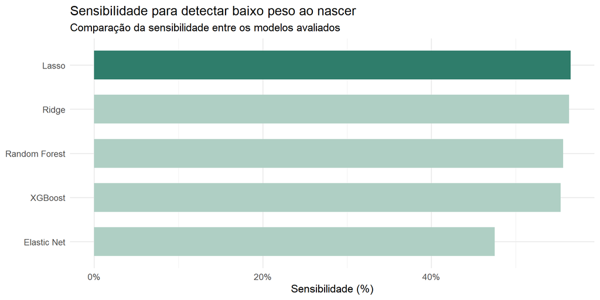

**Figura 4.** Comparação da sensibilidade dos modelos para detectar os casos de baixo peso ao nascer.

Observa-se que o modelo **Lasso** apresentou a maior sensibilidade, seguido pelos modelos Ridge, Random Forest e XGBoost. Embora as diferenças sejam discretas, a escolha do modelo baseou-se na maior proporção de casos de baixo peso ao nascer detectada pelo algoritmo.

## 6.2 Modelo selecionado

Com base no critério previamente estabelecido, o modelo **Lasso** foi selecionado para utilização neste trabalho.

A Tabela 3 resume seus principais indicadores de desempenho.

**Tabela 3**

Indicadores do modelo selecionado

| Modelo | Indicador | Resultado (%) |
| --- | --- | --- |
| Lasso | Acurácia | 63.9 |
| Lasso | Sensibilidade | 56.5 |
| Lasso | Valor Preditivo Positivo (VPP) | 66.3 |
| Lasso | Medida F1 | 61.0 |
| Lasso | AUC-ROC | 68.1 |

Em termos práticos, considerando exclusivamente os recém-nascidos que efetivamente apresentaram baixo peso ao nascer, o modelo sinalizou aproximadamente **57 em cada 100 casos**. Esse resultado corresponde à sensibilidade. Os outros 43 casos, aproximadamente, não seriam sinalizados pelo modelo e constituiriam resultados falso-negativos. Esse percentual não deve ser interpretado como acurácia geral.

Embora exista margem para aprimoramento da capacidade preditiva, o desempenho observado demonstra potencial para utilização do modelo como ferramenta complementar de apoio à decisão em saúde, especialmente quando a identificação precoce dos casos de maior risco constitui prioridade.

Além disso, o Lasso apresentou **ganho de sensibilidade em relação à triagem clínica estimada** a partir dos registros disponíveis na base. Entre os casos que efetivamente apresentaram baixo peso ao nascer, a sensibilidade estimada da triagem foi de cerca de 47%, enquanto a sensibilidade do modelo foi de aproximadamente 56,5%. Isso representa um ganho absoluto de 9,5 pontos percentuais e uma melhora relativa de cerca de 20,2% na capacidade de detectar os casos.

# 7 Aplicação prática dos resultados

A comparação entre os algoritmos permitiu identificar o modelo com melhor desempenho relativo. Entretanto, para avaliar sua utilidade na prática assistencial, é importante compreender de que forma sua utilização pode contribuir para o processo de tomada de decisão em saúde.

Na ausência de um modelo preditivo, a identificação de recém-nascidos com maior probabilidade de apresentar baixo peso depende exclusivamente da avaliação clínica, da experiência da equipe assistencial e da interpretação individual das informações disponíveis durante o acompanhamento pré-natal.

Embora essa abordagem seja indispensável, o grande número de fatores potencialmente associados ao baixo peso ao nascer pode dificultar a avaliação simultânea de todas as informações relevantes.

A utilização de um modelo preditivo não substitui a avaliação clínica, mas acrescenta uma estimativa objetiva de risco construída a partir da combinação de múltiplas características maternas, obstétricas e gestacionais.

## 7.1 Comparação com a triagem clínica estimada

Além da comparação entre os modelos preditivos, foi realizada uma análise complementar para avaliar o possível ganho do modelo em relação a uma triagem clínica baseada nos registros disponíveis na base.

Como a base não possui uma variável única que represente diretamente a decisão profissional de encaminhamento, foi construído um **indicador indireto de triagem clínica**. Esse indicador considera a presença de condições maternas, obstétricas ou comportamentais registradas durante o acompanhamento, associadas a maior risco gestacional.

A comparação foi realizada considerando o baixo peso ao nascer como desfecho de referência. Os casos sinalizados pelo indicador indireto foram tratados como casos priorizados pela triagem clínica estimada, enquanto os demais foram tratados como não priorizados.

| Estratégia | Sensibilidade para detectar baixo peso |
| --- | --- |
| Triagem clínica estimada | 47,0% |
| Modelo Lasso | 56,5% |

Os resultados indicam que a sensibilidade estimada da triagem clínica foi de cerca de **47%**. Com o uso do modelo Lasso, a sensibilidade aumentou para aproximadamente **56,5%**.

Em termos práticos, isso representa um ganho absoluto de aproximadamente **9,5 pontos percentuais** e uma melhora relativa de cerca de **20,2%** na capacidade de detectar os casos de baixo peso ao nascer.

Esse resultado sugere que o modelo pode atuar como ferramenta complementar à triagem clínica, ampliando a capacidade de sinalizar gestantes ou recém-nascidos que poderiam demandar acompanhamento prioritário.

## 7.2 Comparação conceitual

```
flowchart LR

A["Avaliação clínica convencional"]

B["Modelo preditivo"]

A --> C["Estimativa de risco"]

B --> C

C --> D["Apoio à tomada de decisão"]

D --> E["Priorização do acompanhamento"]
```

**Figura 5.** Utilização do modelo como ferramenta complementar ao processo de decisão clínica.

## 7.3 Exemplo de aplicação

Para ilustrar a utilização prática do modelo, considere uma maternidade responsável pelo acompanhamento de **1.000 gestantes**.

Durante o acompanhamento pré-natal, diferentes características clínicas, obstétricas e maternas são registradas para cada gestante. Sem o uso de um modelo preditivo, essas informações são avaliadas principalmente a partir da triagem clínica convencional e da experiência da equipe assistencial.

Com base na comparação realizada neste projeto, a triagem clínica estimada alcançaria aproximadamente **47% dos casos que efetivamente apresentassem baixo peso ao nascer**. Com o uso do modelo Lasso, essa proporção aumentaria para cerca de **56,5%**.

Para ilustrar, suponha que, entre as 1.000 gestantes acompanhadas, 100 efetivamente tivessem bebês com baixo peso. Nesse cenário hipotético, a triagem estimada sinalizaria aproximadamente 47 desses casos, enquanto o modelo alcançaria cerca de 57. Os números absolutos variariam conforme a quantidade real de casos de baixo peso na população atendida.

Em termos práticos, isso significa que o modelo pode ampliar a capacidade de sinalização dos casos de maior risco, oferecendo uma informação adicional para apoiar a priorização do acompanhamento pré-natal.

O modelo não deve ser interpretado como substituto da avaliação clínica, mas como uma ferramenta de apoio capaz de integrar múltiplas informações maternas, obstétricas e clínicas em uma estimativa objetiva de risco.

Essa estimativa pode auxiliar a equipe na identificação precoce de gestantes com maior probabilidade de evoluir para baixo peso ao nascer, contribuindo para o direcionamento de ações preventivas e para a organização do acompanhamento assistencial.

## 7.4 Benefícios potenciais

A utilização do modelo desenvolvido pode contribuir para:

- apoiar a identificação precoce de gestantes com maior risco;
- auxiliar na priorização do acompanhamento pré-natal;
- subsidiar o planejamento de ações preventivas;
- organizar de forma mais eficiente a utilização dos recursos assistenciais;
- fornecer informações adicionais para apoio à decisão clínica.

Ressalta-se que essas contribuições possuem caráter complementar e não substituem a avaliação realizada pelos profissionais de saúde.

# 8 Limitações da aplicação do modelo

A utilização de modelos preditivos em saúde deve ser compreendida como instrumento de apoio à tomada de decisão, e não como substituto da avaliação clínica.

O desempenho observado neste trabalho reflete as características da base de dados utilizada para o desenvolvimento do modelo. Dessa forma, sua aplicação em populações com características distintas pode produzir resultados diferentes dos aqui apresentados.

Além disso, a qualidade das previsões depende diretamente da qualidade das informações utilizadas como entrada. Registros incompletos, inconsistentes ou desatualizados podem comprometer a capacidade preditiva do algoritmo.

Outro aspecto importante refere-se à interpretação dos resultados. A probabilidade estimada representa uma indicação de risco e deve ser analisada em conjunto com os protocolos assistenciais vigentes e com a avaliação clínica realizada pela equipe multiprofissional.

A comparação com a triagem clínica deve ser interpretada com cautela, pois foi realizada a partir de um indicador indireto construído com base nos registros disponíveis, e não a partir de uma variável que represente diretamente a decisão profissional de encaminhamento. Ainda assim, essa análise fornece uma referência prática para avaliar o possível ganho do modelo em relação a uma triagem baseada apenas nos indicadores clínicos registrados.

Assim, recomenda-se que o modelo seja utilizado como ferramenta complementar ao processo de cuidado, contribuindo para a identificação dos indivíduos pertencentes ao grupo de maior risco, sem substituir o julgamento clínico nem os fluxos assistenciais estabelecidos pela instituição.

# 9 Considerações finais

O presente trabalho permitiu desenvolver, treinar e comparar diferentes modelos de aprendizado de máquina aplicados à identificação de recém-nascidos com baixo peso ao nascer.

Entre os algoritmos avaliados, o modelo **Lasso** apresentou a maior Sensibilidade, critério prioritário adotado neste trabalho, detectando a maior proporção dos casos de baixo peso ao nascer entre os modelos comparados. Esse resultado não significa que o Lasso tenha apresentado a maior acurácia ou o maior Valor Preditivo Positivo.

Os resultados obtidos indicam que a utilização de modelos preditivos pode contribuir para o apoio à tomada de decisão em saúde, fornecendo uma estimativa objetiva do risco de baixo peso ao nascer a partir da combinação de informações clínicas, obstétricas e maternas.

Embora o modelo não substitua a avaliação realizada pelos profissionais de saúde, sua utilização pode auxiliar na identificação precoce de gestantes e recém-nascidos que demandem maior atenção, favorecendo o planejamento de ações preventivas, a organização do acompanhamento assistencial e a utilização mais eficiente dos recursos disponíveis.

Espera-se que este relatório contribua para demonstrar o potencial da análise de dados e do aprendizado de máquina como ferramentas de apoio à assistência materno-infantil, reforçando a importância da integração entre conhecimento clínico e tecnologias analíticas no processo de tomada de decisão.